# 04 - G4mer rG4 scores by gene class and mRNA region

Kate

2026-07-28

# Overview

Plot G4mer rG4 scores by gene class, for each mRNA region.

Classes:

- **All mRNAs** - every scored transcript. Note this background *includes* the promoted set rather than excluding it, so it differs from the “All other genes” category used elsewhere in the project. It takes the same grey80 colour slot.
- **eIF3d hypoxia promotes** - `output/genesets/hypoxia_3d_promotes_TE_1hr_lfc0.5.csv` (1604 genes)
- **Negative control** - size-matched to the promoted set within each region, `set.seed(9)`

Reads `output/predictive_modeling/feature_matrix_g4mer.rds`, written by `code/predictive_modeling/01u_feature_extraction_g4mer.Rmd`.

Per-region panels use the native `g4mer_max` (stride 10 for the 5’UTR, stride 20 for CDS and 3’UTR). Within a panel the stride is constant, so it cancels out of any between-class comparison. The final cross-region plot uses `g4mer_max_harmonized`, which places all three regions on a stride-20 grid.

# Load Libraries

```r
library(tidyverse)
library(here)

set.seed(9)
```

```r
group_colors <- c(
  "eIF3d hypoxia promotes" = "#E69F00",
  "Negative control"       = "grey40",
  "All mRNAs"              = "grey80"
)

region_labels <- c(utr5 = "5'UTR", cds = "CDS", utr3 = "3'UTR")
```

# Load Scores

```r
fm_path <- here("output", "predictive_modeling", "feature_matrix_g4mer.rds")
stopifnot("feature_matrix_g4mer.rds not found - knit 01u_ first" = file.exists(fm_path))

g4_wide <- readRDS(fm_path)

g4_long <- g4_wide %>%
  pivot_longer(
    cols          = matches("_(utr5|cds|utr3)$"),
    names_to      = c(".value", "region"),
    names_pattern = "(.*)_(utr5|cds|utr3)$"
  ) %>%
  filter(!is.na(g4mer_max))

stopifnot("expected columns missing after reshape" =
  all(c("g4mer_max", "g4mer_max_harmonized", "gc_pct", "region_length") %in%
      colnames(g4_long)))
stopifnot("g4mer_max outside [0,1]" =
  all(g4_long$g4mer_max >= 0 & g4_long$g4mer_max <= 1))

cat("Scored transcript-region rows:", nrow(g4_long), "\n")
```

```
## Scored transcript-region rows: 29267
```

```r
g4_long %>% dplyr::count(region)
```

```
## # A tibble: 3 × 2
##   region     n
##   <chr>  <int>
## 1 cds    10025
## 2 utr3    9697
## 3 utr5    9545
```

# Define Gene Classes

```r
promotes <- read_csv(here("output", "genesets", "hypoxia_3d_promotes_TE_1hr_lfc0.5.csv"),
                     show_col_types = FALSE) %>%
  pull(ensembl_gene) %>% unique()

stopifnot("Expected 1604 eIF3d hypoxia-promoted genes" = length(promotes) == 1604)
cat("eIF3d hypoxia-promoted genes in geneset:", length(promotes), "\n")
```

```
## eIF3d hypoxia-promoted genes in geneset: 1604
```

```r
neg_pool <- read_csv(here("output", "predictive_modeling", "negative_control_genes.csv"),
                     show_col_types = FALSE) %>%
  mutate(gene_id_clean = sub("\\..*", "", gene_id)) %>%
  pull(gene_id_clean) %>% unique()
cat("Negative control pool:", length(neg_pool), "genes\n")
```

```
## Negative control pool: 3319 genes
```

```r
# Size-match within each region: the number of promoted genes carrying an
# annotated region differs between regions.
set.seed(9)
matched_neg <- g4_long %>%
  group_by(region) %>%
  group_modify(function(d, key) {
    n_pos     <- sum(d$gene_id_clean %in% promotes)
    available <- intersect(neg_pool, d$gene_id_clean)
    tibble(gene_id_clean = sample(available, min(n_pos, length(available))))
  }) %>%
  ungroup()

dat <- g4_long %>%
  left_join(matched_neg %>% mutate(is_neg = TRUE),
            by = c("region", "gene_id_clean")) %>%
  mutate(
    is_neg = replace_na(is_neg, FALSE),
    class  = case_when(
      gene_id_clean %in% promotes ~ "eIF3d hypoxia promotes",
      is_neg                      ~ "Negative control",
      TRUE                        ~ NA_character_
    )
  )

# "All mRNAs" overlaps the other two classes, so it is stacked on rather than
# assigned exclusively.
plot_dat <- bind_rows(
  dat %>% filter(!is.na(class)),
  dat %>% mutate(class = "All mRNAs")
) %>%
  mutate(
    class      = factor(class, levels = names(group_colors)),
    region_lab = factor(region_labels[region], levels = region_labels)
  )

plot_dat %>% dplyr::count(region_lab, class)
```

```
## # A tibble: 9 × 3
##   region_lab class                      n
##   <fct>      <fct>                  <int>
## 1 5'UTR      eIF3d hypoxia promotes  1338
## 2 5'UTR      Negative control        1338
## 3 5'UTR      All mRNAs               9545
## 4 CDS        eIF3d hypoxia promotes  1393
## 5 CDS        Negative control        1393
## 6 CDS        All mRNAs              10025
## 7 3'UTR      eIF3d hypoxia promotes  1358
## 8 3'UTR      Negative control        1358
## 9 3'UTR      All mRNAs               9697
```

# Statistics

```r
stats_tbl <- plot_dat %>%
  group_by(region_lab) %>%
  group_modify(function(d, key) {
    pos <- d$g4mer_max[d$class == "eIF3d hypoxia promotes"]
    neg <- d$g4mer_max[d$class == "Negative control"]
    all <- d$g4mer_max[d$class == "All mRNAs"]
    tibble(
      n_pos        = length(pos),
      n_neg        = length(neg),
      n_all        = length(all),
      med_pos      = median(pos),
      med_neg      = median(neg),
      med_all      = median(all),
      p_pos_vs_neg = wilcox.test(pos, neg)$p.value,
      p_pos_vs_all = wilcox.test(pos, all)$p.value
    )
  }) %>% ungroup()

stats_tbl %>%
  mutate(across(starts_with("med_"), ~ round(.x, 4)),
         across(starts_with("p_"), ~ format.pval(.x, digits = 3))) %>%
  print(width = Inf)
```

```
## # A tibble: 3 × 9
##   region_lab n_pos n_neg n_all med_pos med_neg med_all p_pos_vs_neg p_pos_vs_all
##   <fct>      <int> <int> <int>   <dbl>   <dbl>   <dbl> <chr>        <chr>
## 1 5'UTR       1338  1338  9545  0.257    0.157   0.189 0.000766     0.00154
## 2 CDS         1393  1393 10025  0.0804   0.474   0.227 < 2e-16      < 2e-16
## 3 3'UTR       1358  1358  9697  0.125    0.284   0.206 < 2e-16      < 2e-16
```

```r
# Annotation label carries n, per project convention
annot <- stats_tbl %>%
  mutate(label = sprintf("promotes vs neg ctrl p = %s\nn = %d vs %d",
                         format.pval(p_pos_vs_neg, digits = 3), n_pos, n_neg))
```

```r
base_theme <- theme_classic(base_size = 12) + theme(legend.position = "bottom")
```

# Density

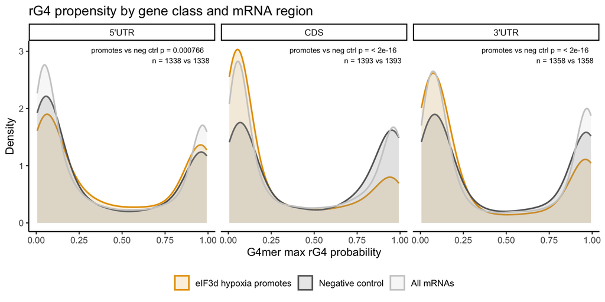

```r
p_density <- ggplot(plot_dat, aes(x = g4mer_max, fill = class, colour = class)) +
  geom_density(alpha = 0.15, linewidth = 0.8) +
  facet_wrap(~ region_lab) +
  scale_fill_manual(values = group_colors) +
  scale_colour_manual(values = group_colors) +
  geom_text(data = annot, inherit.aes = FALSE,
            aes(x = Inf, y = Inf, label = label),
            hjust = 1.1, vjust = 1.4, size = 2.8) +
  labs(x = "G4mer max rG4 probability", y = "Density",
       fill = NULL, colour = NULL,
       title = "rG4 propensity by gene class and mRNA region") +
  base_theme

print(p_density)
```

```r
ggsave(here("plots", "g4mer_04_density_by_class.pdf"), p_density,
       width = 9, height = 4.5)
```

# Violin and Box

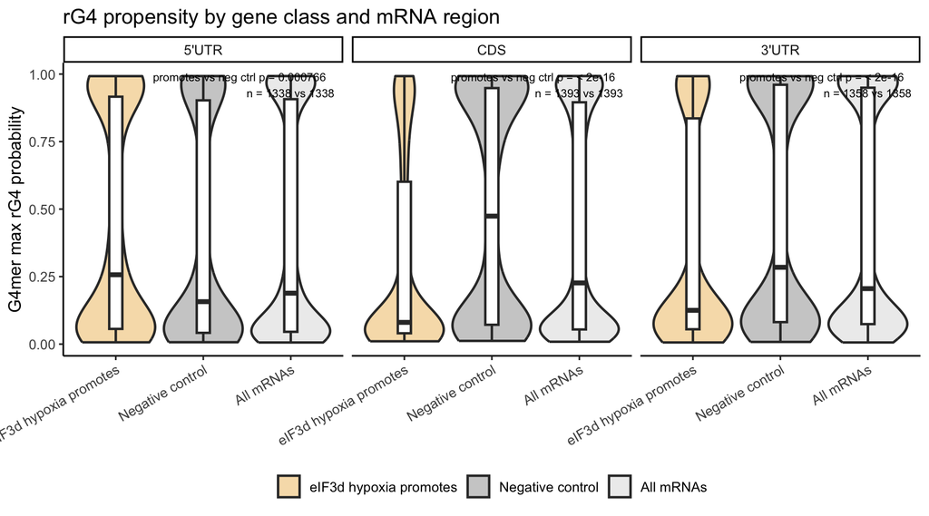

```r
p_violin <- ggplot(plot_dat, aes(x = class, y = g4mer_max, fill = class)) +
  geom_violin(alpha = 0.35, linewidth = 0.8, scale = "width") +
  geom_boxplot(width = 0.15, outlier.shape = NA, linewidth = 0.8, fill = "white") +
  facet_wrap(~ region_lab) +
  scale_fill_manual(values = group_colors) +
  geom_text(data = annot, inherit.aes = FALSE,
            aes(x = Inf, y = Inf, label = label),
            hjust = 1.1, vjust = 1.4, size = 2.8) +
  labs(x = NULL, y = "G4mer max rG4 probability", fill = NULL,
       title = "rG4 propensity by gene class and mRNA region") +
  base_theme +
  theme(axis.text.x = element_text(angle = 30, hjust = 1))

print(p_violin)
```

```r
ggsave(here("plots", "g4mer_04_violin_by_class.pdf"), p_violin,
       width = 9, height = 5)
```

# ECDF

These distributions are strongly bimodal, with most transcripts near 0 and a cluster near 1. An ECDF avoids the bandwidth smoothing that can hide that structure in a density plot.

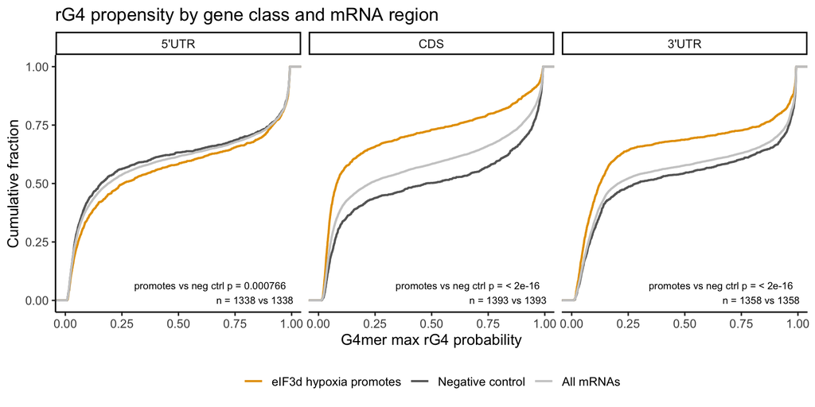

```r
p_ecdf <- ggplot(plot_dat, aes(x = g4mer_max, colour = class)) +
  stat_ecdf(linewidth = 0.8) +
  facet_wrap(~ region_lab) +
  scale_colour_manual(values = group_colors) +
  geom_text(data = annot, inherit.aes = FALSE,
            aes(x = Inf, y = -Inf, label = label),
            hjust = 1.1, vjust = -0.4, size = 2.8) +
  labs(x = "G4mer max rG4 probability", y = "Cumulative fraction",
       colour = NULL,
       title = "rG4 propensity by gene class and mRNA region") +
  base_theme

print(p_ecdf)
```

```r
ggsave(here("plots", "g4mer_04_ecdf_by_class.pdf"), p_ecdf, width = 9, height = 4.5)
```

# Cross-Region at Matched Stride

The 5’UTR was scored at stride 10 and CDS/3’UTR at stride 20, so only the harmonized score is comparable across regions. The plots above compare classes *within* a region, where stride is constant and cancels.

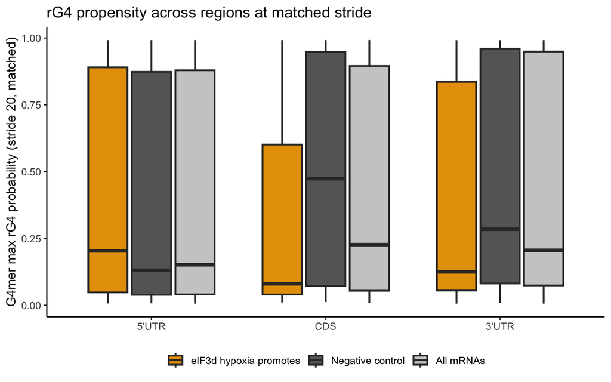

```r
p_harm <- ggplot(plot_dat, aes(x = region_lab, y = g4mer_max_harmonized,
                               fill = class)) +
  geom_boxplot(outlier.size = 0.3, outlier.alpha = 0.2, linewidth = 0.8) +
  scale_fill_manual(values = group_colors) +
  labs(x = NULL, y = "G4mer max rG4 probability (stride 20, matched)",
       fill = NULL,
       title = "rG4 propensity across regions at matched stride") +
  base_theme

print(p_harm)
```

```r
ggsave(here("plots", "g4mer_04_cross_region_matched_stride.pdf"), p_harm,
       width = 8, height = 5)
```